# Wine Features

Author

Tatum Good

**Abstract:**

This is a technical blog post of **both** an HTML file *and* .qmd file hosted on GitHub pages.

# **Step Up Code:**

```r
library(tidyverse)
library(caret)
library(fastDummies)
wine <- readRDS(gzcon(url("https://github.com/cd-public/D505/raw/master/dat/wine.rds")))
```

**Explanataion:**

> - line 17: loads un the tidyverse library

> - line 18: loads in the caret library

> - line 19: loads in the fastDummies library

> - line 20: reads in the ‘wine.rds’ file that has the wine dataset

```
samp<-sample_n(wine, 10000)
```

> selects 10,000 random froms from our wine dataset to reduce computational load (have fixed my issue so unneeded)

# Feature Engineering

We begin by engineering an number of features.

1. Create a total of 10 features (including points).
2. Remove all rows with a missing value.
3. Ensure only log(price) and engineering features are the only columns that remain in the `wino` dataframe.

```r
wino <- wine %>%
  mutate(
    lprice = log(price),  #log transformation of price
    is_premium = ifelse(price > median(price, na.rm = TRUE), 1, 0),  # binary: premium wine
    age = 2025 - year,  #computes wine age
    high_quality = ifelse(points >= 90, 1, 0),  # binary: high quality
    province_encoded = as.numeric(as.factor(province)),  # encodes province as numeric factor
    region_encoded = as.numeric(as.factor(region_1)),  # encodes region_1 as numeric factor
    winery_encoded = as.numeric(as.factor(winery)),  # encodes winery as numeric factor
    variety_encoded = as.numeric(as.factor(variety)),  # encodes variety as numeric factor
    description_length = nchar(description),  # calculates the length of the wine description
    word_count = str_count(description, "\\s+") + 1  # word count in description
  ) %>%
  drop_na() %>%  #removes missing values
  select(lprice, points, is_premium, age, high_quality, province_encoded, region_encoded,
         winery_encoded, variety_encoded, description_length, word_count)  #keeps only selected features
```

> I have added in comments next to each line to describe what it is doing.

# Caret

We now use a train/test split to evaluate the features.

1. Use the Caret library to partition the wino dataframe into an 80/20 split.
2. Run a linear regression with bootstrap resampling.
3. Report RMSE on the test partition of the data.

```r
# Train/Test Split
#set.seed(5)
train_index <- createDataPartition(wino$lprice, p = 0.8, list = FALSE)
train_data <- wino[train_index, ]
test_data <- wino[-train_index, ]
```

> Splits the dataset into 80% training and 20% testing based on lprice.

```r
# Train Model using Linear Regression with Bootstrap Resampling
model <- train(lprice ~ ., #lprice ~ points + winery_encoded,
      data=train_data,
      method="lm",
      trControl = trainControl(method = "boot", number = 100))
```

> I am first making a split for my training and testing data from the new wino dataset. I then create a model using the bootstrap resampling and our train_data. It took forever for it to run “number = 100” because I errored in my code earlier. This code now uses bootstrap resampling with 100 iterations.

```r
# Make Predictions
predictions <- predict(model, test_data)

# Calculate RMSE
rmse <- RMSE(predictions, test_data$lprice)
rmse1<- sqrt(mean((predictions - test_data$lprice)^2))

# Print RMSE
print(paste("Test RMSE:", round(rmse, 3)))
```

```
[1] "Test RMSE: 0.331"
```

> This first generates predictions on the test data. I can then calculate the RMSE to measure model accuracy. I then computed RMSE manually (using sqrt) just to verify.

# Variable selection

We now graph the importance of your 10 features.

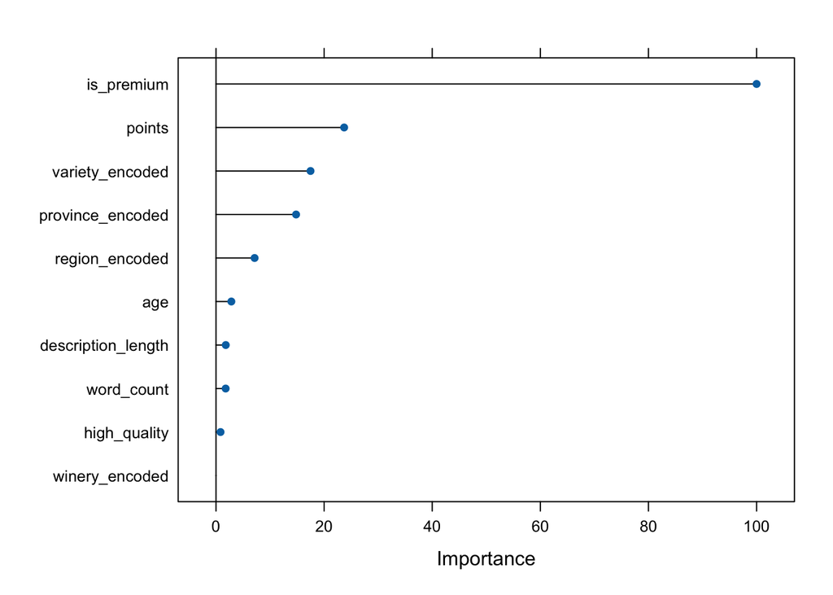

```r
# Plot Feature Importance
importance <- varImp(model)
plot(importance)
```

> This should compute feature importance scores based on the trained model. Then plot generates a visualization showing the relative importance of each feature